# Part I - Ford Gobike Trip Data

## Introduction

> This data set includes information about individual rides made in a bike-sharing system covering the greater San Francisco Bay area. including: Duration, Start/End time, Start/End Stations data names, City, , Users data (Year of birth, gender), bike share for all trip.

## Preliminary Wrangling

```python
# import all packages and set plots to be embedded inline
import numpy as np
import pandas as pd
import matplotlib.pyplot as plt
import seaborn as sb
import datetime
from geopy.geocoders import Nominatim

%matplotlib inline
```

```python
bikedata = pd.read_csv('fordgobike-tripdata.csv')
```

```python
bikedata.head()
```

|  | duration_sec | start_time | end_time | start_station_id | start_station_name | start_station_latitude | start_station_longitude | end_station_id | end_station_name | end_station_latitude | end_station_longitude | bike_id | user_type | member_birth_year | member_gender | bike_share_for_all_trip |
| --- | --- | --- | --- | --- | --- | --- | --- | --- | --- | --- | --- | --- | --- | --- | --- | --- |
| 0 | 52185 | 2019-02-28 17:32:10.1450 | 2019-03-01 08:01:55.9750 | 21.0 | Montgomery St BART Station (Market St at 2nd St) | 37.789625 | -122.400811 | 13.0 | Commercial St at Montgomery St | 37.794231 | -122.402923 | 4902 | Customer | 1984.0 | Male | No |
| 1 | 42521 | 2019-02-28 18:53:21.7890 | 2019-03-01 06:42:03.0560 | 23.0 | The Embarcadero at Steuart St | 37.791464 | -122.391034 | 81.0 | Berry St at 4th St | 37.775880 | -122.393170 | 2535 | Customer | NaN | NaN | No |
| 2 | 61854 | 2019-02-28 12:13:13.2180 | 2019-03-01 05:24:08.1460 | 86.0 | Market St at Dolores St | 37.769305 | -122.426826 | 3.0 | Powell St BART Station (Market St at 4th St) | 37.786375 | -122.404904 | 5905 | Customer | 1972.0 | Male | No |
| 3 | 36490 | 2019-02-28 17:54:26.0100 | 2019-03-01 04:02:36.8420 | 375.0 | Grove St at Masonic Ave | 37.774836 | -122.446546 | 70.0 | Central Ave at Fell St | 37.773311 | -122.444293 | 6638 | Subscriber | 1989.0 | Other | No |
| 4 | 1585 | 2019-02-28 23:54:18.5490 | 2019-03-01 00:20:44.0740 | 7.0 | Frank H Ogawa Plaza | 37.804562 | -122.271738 | 222.0 | 10th Ave at E 15th St | 37.792714 | -122.248780 | 4898 | Subscriber | 1974.0 | Male | Yes |

```python
bikedata.info()
```

```
<class 'pandas.core.frame.DataFrame'>
RangeIndex: 183412 entries, 0 to 183411
Data columns (total 16 columns):
 #   Column                   Non-Null Count   Dtype
---  ------                   --------------   -----
 0   duration_sec             183412 non-null  int64
 1   start_time               183412 non-null  object
 2   end_time                 183412 non-null  object
 3   start_station_id         183215 non-null  float64
 4   start_station_name       183215 non-null  object
 5   start_station_latitude   183412 non-null  float64
 6   start_station_longitude  183412 non-null  float64
 7   end_station_id           183215 non-null  float64
 8   end_station_name         183215 non-null  object
 9   end_station_latitude     183412 non-null  float64
 10  end_station_longitude    183412 non-null  float64
 11  bike_id                  183412 non-null  int64
 12  user_type                183412 non-null  object
 13  member_birth_year        175147 non-null  float64
 14  member_gender            175147 non-null  object
 15  bike_share_for_all_trip  183412 non-null  object
dtypes: float64(7), int64(2), object(7)
memory usage: 22.4+ MB
```

### Data Wrangling:

```python
#change latitudes, longtitudes to strings:
for coordinate in  ['start_station_latitude','start_station_longitude','end_station_latitude','end_station_longitude']:
    bikedata[coordinate] = bikedata[coordinate].astype(str)

#change IDs to strings:
bikedata['start_station_id'].fillna(0,inplace=True)
bikedata['end_station_id'].fillna(0,inplace=True)
for id in ['start_station_id', 'end_station_id', 'bike_id']:
    bikedata[id] = bikedata[id].astype('int64')
    bikedata[id] = bikedata[id].astype(str)
bikedata['start_station_id'] = bikedata['start_station_id'].replace('0', None)
bikedata['end_station_id'] = bikedata['end_station_id'].replace('0', None)

#change member's year of birth to integer:
bikedata['member_birth_year'] = bikedata['member_birth_year'].astype('Int64')

#change start/end time to datetime:
for time in ['start_time', 'end_time']:
    bikedata[time] = bikedata[time].astype('datetime64[ns]')
```

```python
#Create a 'duration' Column in "hour:minute:second" format:
bikedata['duration(h:m:s)'] = pd.to_datetime(bikedata['duration_sec'], unit='s').dt.strftime('%H:%M:%S')
#Move the 'duration' column to the 2nd position
duration_col = bikedata.pop('duration(h:m:s)')
bikedata.insert(1, 'duration(h:m:s)', duration_col)
```

```python
#Create a new column of member age (at 2019):
bikedata['member_age'] = 2019 - bikedata['member_birth_year']
#Move the column next to member_birth_year:
age_col = bikedata.pop('member_age')
bikedata.insert(bikedata.columns.get_loc('member_gender'), 'member_age', age_col)
```

```python
#Show missing values:
bikedata.isna().sum()
```

```
duration_sec                  0
duration(h:m:s)               0
start_time                    0
end_time                      0
start_station_id            197
start_station_name          197
start_station_latitude        0
start_station_longitude       0
end_station_id              197
end_station_name            197
end_station_latitude          0
end_station_longitude         0
bike_id                       0
user_type                     0
member_birth_year          8265
member_age                 8265
member_gender              8265
bike_share_for_all_trip       0
dtype: int64
```

> It looks like there're 197 entries have unregistered stations without their ID/names

```python
#Create a dataframe of stations:
station = bikedata[['start_station_id','start_station_name','start_station_latitude','start_station_longitude']]
station = station.drop_duplicates()
```

```python
station.info()
```

```
<class 'pandas.core.frame.DataFrame'>
Int64Index: 343 entries, 0 to 156498
Data columns (total 4 columns):
 #   Column                   Non-Null Count  Dtype
---  ------                   --------------  -----
 0   start_station_id         329 non-null    object
 1   start_station_name       329 non-null    object
 2   start_station_latitude   343 non-null    object
 3   start_station_longitude  343 non-null    object
dtypes: object(4)
memory usage: 13.4+ KB
```

> --> 14 unamed/no ID stations

```python
#Make a Nominatim object and initialize Nominatim API with the geoapiExercises parameter.
geolocator = Nominatim(user_agent="geoapiExercises")
```

```python
#create a city column for the station:
station['city'] = np.NAN
for index in station.index:
    location = geolocator.reverse((station.loc[index,'start_station_latitude'],station.loc[index,'start_station_longitude']))
    adress = location.raw['address']
    try:
        station.loc[index,'city'] = adress['city']
    except:
        station.loc[index,'city'] = None
```

```python
#Show stations that can't find their city:
station[station['city'].isna()]
```

|  | start_station_id | start_station_name | start_station_latitude | start_station_longitude | city |
| --- | --- | --- | --- | --- | --- |
| 186 | 148 | Horton St at 40th St | 37.8297046 | -122.2876102 | None |
| 212 | 155 | Emeryville Public Market | 37.84052116694969 | -122.29352831840517 | None |
| 285 | 154 | Doyle St at 59th St | 37.8419238 | -122.2880451 | None |
| 307 | 149 | Emeryville Town Hall | 37.8312752 | -122.2856333 | None |
| 411 | 150 | Adeline St at 40th St | 37.8312769 | -122.2782669 | None |
| 600 | 156 | Stanford Ave at Hollis St | 37.8384435 | -122.2886647 | None |
| 618 | 151 | 53rd St at Hollis St | 37.8361823 | -122.2871801 | None |
| 1549 | 152 | 47th St at San Pablo Ave | 37.83563220458518 | -122.28105068206789 | None |
| 2352 | 153 | 59th St at Horton St | 37.8409452 | -122.2913604 | None |
| 2578 | 157 | 65th St at Hollis St | 37.8467842 | -122.2913761 | None |
| 8499 | None | NaN | 37.41 | -121.96 | None |

> Based on the coordinates, it looks like all of the stations above are located in Emeryville - California, exept for the one w. no name is in San Jose. However, the geopy' APIs can point that out, so I add city for those stations manually:

```python
station['city'] = station['city'].fillna('Emeryville')
station.loc[(station['start_station_latitude'] == '37.41') &
            (station['start_station_longitude'] == '-121.96'), 'city'] = 'San Jose'
```

```python
# Merge the two dataframes based on the latitude and longitude columns
merged_data = pd.merge(bikedata, station, on=['start_station_latitude', 'start_station_longitude'], how='left')
```

```python
# Update the stations' cities in the bikedata dataframe
bikedata['city'] = np.NaN
bikedata['city'].fillna(merged_data['city'], inplace=True)
```

#### The updated 'bikedata' dataset:

```python
bikedata.head()
```

|  | duration_sec | duration(h:m:s) | start_time | end_time | start_station_id | start_station_name | start_station_latitude | start_station_longitude | end_station_id | end_station_name | end_station_latitude | end_station_longitude | bike_id | user_type | member_birth_year | member_age | member_gender | bike_share_for_all_trip | city |
| --- | --- | --- | --- | --- | --- | --- | --- | --- | --- | --- | --- | --- | --- | --- | --- | --- | --- | --- | --- |
| 0 | 52185 | 14:29:45 | 2019-02-28 17:32:10.145 | 2019-03-01 08:01:55.975 | 21 | Montgomery St BART Station (Market St at 2nd St) | 37.7896254 | -122.400811 | 13 | Commercial St at Montgomery St | 37.794231 | -122.402923 | 4902 | Customer | 1984 | 35 | Male | No | San Francisco |
| 1 | 42521 | 11:48:41 | 2019-02-28 18:53:21.789 | 2019-03-01 06:42:03.056 | 23 | The Embarcadero at Steuart St | 37.791464 | -122.391034 | 81 | Berry St at 4th St | 37.77588 | -122.39317 | 2535 | Customer | <NA> | <NA> | NaN | No | San Francisco |
| 2 | 61854 | 17:10:54 | 2019-02-28 12:13:13.218 | 2019-03-01 05:24:08.146 | 86 | Market St at Dolores St | 37.7693053 | -122.4268256 | 3 | Powell St BART Station (Market St at 4th St) | 37.78637526861584 | -122.40490436553954 | 5905 | Customer | 1972 | 47 | Male | No | San Francisco |
| 3 | 36490 | 10:08:10 | 2019-02-28 17:54:26.010 | 2019-03-01 04:02:36.842 | 375 | Grove St at Masonic Ave | 37.77483629413345 | -122.44654566049576 | 70 | Central Ave at Fell St | 37.77331087889723 | -122.44429260492323 | 6638 | Subscriber | 1989 | 30 | Other | No | San Francisco |
| 4 | 1585 | 00:26:25 | 2019-02-28 23:54:18.549 | 2019-03-01 00:20:44.074 | 7 | Frank H Ogawa Plaza | 37.8045623549303 | -122.27173805236816 | 222 | 10th Ave at E 15th St | 37.7927143 | -122.2487796 | 4898 | Subscriber | 1974 | 45 | Male | Yes | Oakland |

Create the dataset 'bikedata_explore' to used for exploration:

```python
#Create the dataset for exploratoration, only keeps the keys data columns:
bikedata_explore = bikedata.drop(['start_station_id','start_station_latitude',
                                          'start_station_longitude','end_station_id',
                                          'end_station_latitude','end_station_longitude',
                                          'bike_id','member_birth_year'],axis=1)
```

```python
#Move the 'city' column:
city_col = bikedata_explore.pop('city')
bikedata_explore.insert(bikedata_explore.columns.get_loc('start_station_name'), 'city', city_col)
# Convert duration from seconds to minutes
bikedata_explore['Duration_minutes'] = bikedata_explore['duration_sec'] / 60
```

```python
bikedata_explore
```

|  | duration_sec | duration(h:m:s) | start_time | end_time | city | start_station_name | end_station_name | user_type | member_age | member_gender | bike_share_for_all_trip | Duration_minutes |
| --- | --- | --- | --- | --- | --- | --- | --- | --- | --- | --- | --- | --- |
| 0 | 52185 | 14:29:45 | 2019-02-28 17:32:10.145 | 2019-03-01 08:01:55.975 | San Francisco | Montgomery St BART Station (Market St at 2nd St) | Commercial St at Montgomery St | Customer | 35 | Male | No | 869.750000 |
| 1 | 42521 | 11:48:41 | 2019-02-28 18:53:21.789 | 2019-03-01 06:42:03.056 | San Francisco | The Embarcadero at Steuart St | Berry St at 4th St | Customer | <NA> | NaN | No | 708.683333 |
| 2 | 61854 | 17:10:54 | 2019-02-28 12:13:13.218 | 2019-03-01 05:24:08.146 | San Francisco | Market St at Dolores St | Powell St BART Station (Market St at 4th St) | Customer | 47 | Male | No | 1030.900000 |
| 3 | 36490 | 10:08:10 | 2019-02-28 17:54:26.010 | 2019-03-01 04:02:36.842 | San Francisco | Grove St at Masonic Ave | Central Ave at Fell St | Subscriber | 30 | Other | No | 608.166667 |
| 4 | 1585 | 00:26:25 | 2019-02-28 23:54:18.549 | 2019-03-01 00:20:44.074 | Oakland | Frank H Ogawa Plaza | 10th Ave at E 15th St | Subscriber | 45 | Male | Yes | 26.416667 |
| ... | ... | ... | ... | ... | ... | ... | ... | ... | ... | ... | ... | ... |
| 183407 | 480 | 00:08:00 | 2019-02-01 00:04:49.724 | 2019-02-01 00:12:50.034 | San Francisco | Beale St at Harrison St | Union Square (Powell St at Post St) | Subscriber | 23 | Male | No | 8.000000 |
| 183408 | 313 | 00:05:13 | 2019-02-01 00:05:34.744 | 2019-02-01 00:10:48.502 | San Francisco | Montgomery St BART Station (Market St at 2nd St) | 3rd St at Townsend St | Subscriber | 35 | Male | No | 5.216667 |
| 183409 | 141 | 00:02:21 | 2019-02-01 00:06:05.549 | 2019-02-01 00:08:27.220 | San Jose | The Alameda at Bush St | Morrison Ave at Julian St | Subscriber | 29 | Male | Yes | 2.350000 |
| 183410 | 139 | 00:02:19 | 2019-02-01 00:05:34.360 | 2019-02-01 00:07:54.287 | Oakland | San Pablo Ave at MLK Jr Way | San Pablo Ave at 27th St | Subscriber | 31 | Male | No | 2.316667 |
| 183411 | 271 | 00:04:31 | 2019-02-01 00:00:20.636 | 2019-02-01 00:04:52.058 | San Francisco | Spear St at Folsom St | 2nd St at Folsom St | Subscriber | 30 | Male | No | 4.516667 |

183412 rows × 12 columns

```python
bikedata_explore.info()
```

```
<class 'pandas.core.frame.DataFrame'>
RangeIndex: 183412 entries, 0 to 183411
Data columns (total 12 columns):
 #   Column                   Non-Null Count   Dtype
---  ------                   --------------   -----
 0   duration_sec             183412 non-null  int64
 1   duration(h:m:s)          183412 non-null  object
 2   start_time               183412 non-null  datetime64[ns]
 3   end_time                 183412 non-null  datetime64[ns]
 4   city                     183412 non-null  object
 5   start_station_name       183215 non-null  object
 6   end_station_name         183215 non-null  object
 7   user_type                183412 non-null  object
 8   member_age               175147 non-null  Int64
 9   member_gender            175147 non-null  object
 10  bike_share_for_all_trip  183412 non-null  object
 11  Duration_minutes         183412 non-null  float64
dtypes: Int64(1), datetime64[ns](2), float64(1), int64(1), object(7)
memory usage: 17.0+ MB
```

### What is the structure of your dataset?

> The dataset contains data of 183412 rides in Feb 2019 of the Ford Gobike bike-sharing system, with 12 detailed info, including: Duration, Start/End time, Start/End Stations data names, City, , Users data (Year of birth, gender), bike share for all trip. I added the column 'city' which tells the city of the station the bike was taken for each ride. The 'member_age' column contains customer ages (at 2019). The duration(h:m:s) column with the duration of each ride in Hours:Minutes:Seconds format.

### What is/are the main feature(s) of interest in your dataset?

> - The duration of bike rides.

### What features in the dataset do you think will help support your investigation into your feature(s) of interest?

> - How long does the average trip take?

> The relation of trips duration to:
> - If a user is a subscriber or customer.
> - The city the those trips taken place.
> - The ages of users.
> - User's gender.
> - Trip start time.
> - Bike sharing option for their trips.

## Univariate Exploration

`1.` Distribution of trips duration:

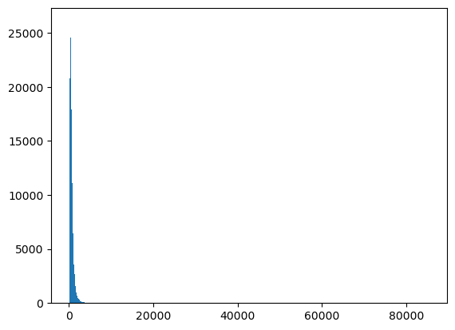

```python
#Distribution of trips duration:
base_color = sb.color_palette()[0];
bins = np.arange(60,bikedata_explore['duration_sec'].max()+10,100);
plt.hist(data=bikedata_explore, x='duration_sec',color=base_color,bins = bins);
```

```
Average trip duration of Feb 2019: 12.10130725724962 (minutes)
```

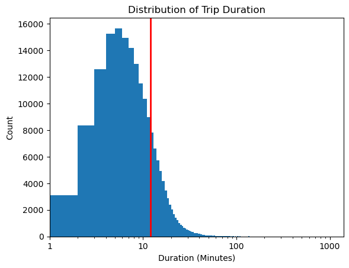

```python
#The Duration distribution in log scale:
bins=np.arange(0,1400,1)
plt.hist(data=bikedata_explore,x='Duration_minutes',bins=bins)
plt.xscale('log')
plt.xlim(1,1400)
x_ticklocs=[1,10,100,1000]
x_ticklabels=['1','10','100','1000']
plt.xticks(x_ticklocs, x_ticklabels)
plt.xlabel('Duration (Minutes)')
plt.ylabel('Count')
plt.title('Distribution of Trip Duration');
#Trip duration mean value:
duration_mean = np.mean(bikedata_explore['Duration_minutes'])
print(f'Average trip duration of Feb 2019: {duration_mean} (minutes)')
plt.axvline(duration_mean,color='r', linewidth=2);
```

> The distribution of duration (in minutes) peaks at around 16,000 with the mean vavlue of 12.1. And it has a very long right tail

`2.` Number of trips by duration ranges:

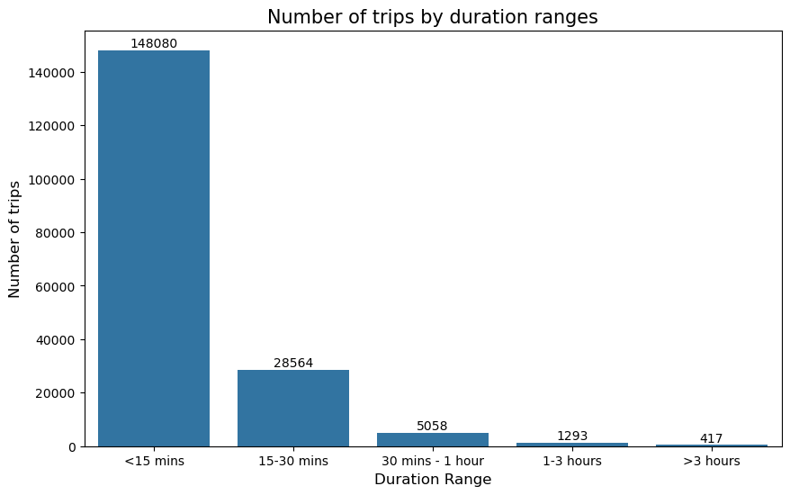

```python
# Create a new column for duration ranges
bikedata_explore['Duration_Range'] = pd.cut(bikedata_explore['Duration_minutes'], bins=[0, 15, 30, 60, 180, float('inf')], labels=['<15 mins', '15-30 mins', '30 mins - 1 hour', '1-3 hours', '>3 hours'])
# Count the number of occurrences in each range
count = bikedata_explore['Duration_Range'].value_counts()
# Create a count plot
plt.figure(figsize=(10, 6))
sb.barplot(x=count.index, y=count.values,color=base_color)
plt.xlabel('Duration Range',size=12)
plt.ylabel('Number of trips',size=12)
plt.title('Number of trips by duration ranges',size=15)
for i, v in enumerate(count.values):
    plt.text(i, v, str(v), ha='center', va='bottom')
plt.show();
```

> Most of the trips are less than 15 minutes. While the figure for the trips within 15-30 minutes was 28,564. Trips takes more than 1 hours only hold small percentage of the total figure.

`3.` Number of trips per by the start hours of the day/days of month/month of the years:

```python
"""
    Creates a countplot of entries by each hour of the day/days of the week/days of February using a datetime column.

    Parameters:
    time_get (str): The time unit to process data. Valid values are 'hour', 'day_week', 'day_month'.

    Returns:
    None
"""
def time_dist(time_get):
    bikedata_explore_cp = bikedata_explore.copy() #a copy dataset to create hour/day columns
    if time_get == 'hour':
        bikedata_explore_cp['starttime'] = bikedata_explore_cp['start_time'].dt.hour
        time_1 = 'hour'
        time_2 = 'day'
        order = None
    elif time_get == 'day_week':
        bikedata_explore_cp['starttime'] = bikedata_explore_cp['start_time'].dt.strftime("%A")
        time_1 = 'day'
        time_2 = 'week'
        order = ('Monday','Tuesday','Wednesday','Thursday','Friday','Saturday','Sunday')
    elif time_get == 'day_month':
        bikedata_explore_cp['starttime'] = bikedata_explore_cp['start_time'].dt.day
        time_1 = 'day'
        time_2 = 'month'
        order = None
    plt.figure(figsize=(8,8))
    sb.countplot(data=bikedata_explore_cp, x='starttime',color=base_color,order = order)
    plt.xlabel(f'{time_1}s of the {time_2}')
    plt.ylabel('Number of trips')
    plt.title(f'Trips by {time_1}s of the {time_2}')
    plt.show()
```

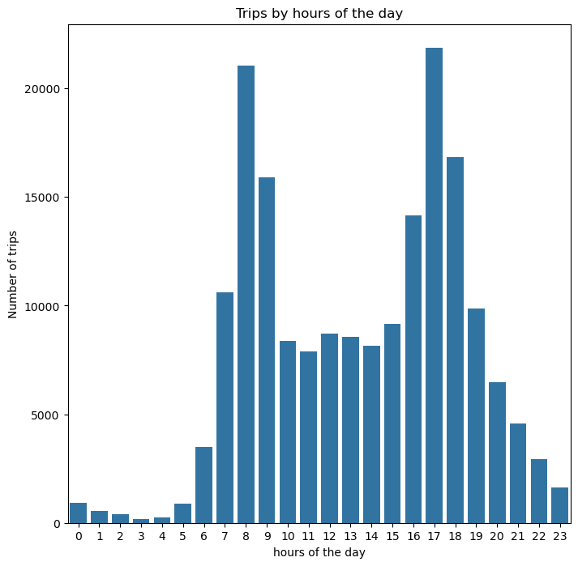

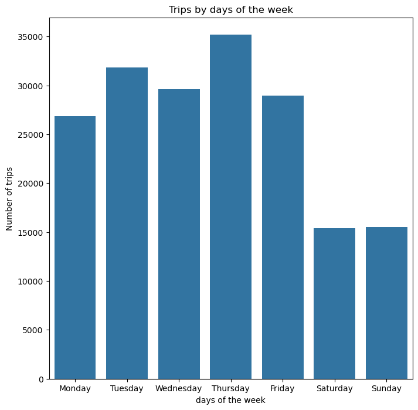

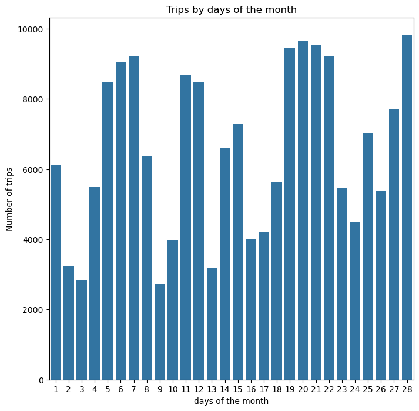

```python
for i_time in ('hour','day_week','day_month'):
    time_dist(i_time)
```

> `i.` Daily: 8AM, 9AM, 4PM, 5PM, 6PM are the most common start hour of the trips.  
> `ii.` Weekly: Users has the tendency to start trips in weekdays more than in weekends.  
> `iii.` Monthly: days 2nd, 3rd, 9th, 13th, 16th and 17th observed the lowest number in trips start.

`4.` Number of trips in each city:

```python
#Number of trips by each city:
bikedata_explore['city'].value_counts()
```

```
San Francisco    133708
Oakland           20434
Berkeley          19449
San Jose           8268
Emeryville         1551
Santa Clara           2
Name: city, dtype: int64
```

```python
bikedata[bikedata['city'] == 'Santa Clara']
```

|  | duration_sec | duration(h:m:s) | start_time | end_time | start_station_id | start_station_name | start_station_latitude | start_station_longitude | end_station_id | end_station_name | end_station_latitude | end_station_longitude | bike_id | user_type | member_birth_year | member_age | member_gender | bike_share_for_all_trip | city |
| --- | --- | --- | --- | --- | --- | --- | --- | --- | --- | --- | --- | --- | --- | --- | --- | --- | --- | --- | --- |
| 128358 | 1796 | 00:29:56 | 2019-02-10 13:06:13.186 | 2019-02-10 13:36:09.883 | None | NaN | 37.38 | -121.94 | None | NaN | 37.41 | -121.93 | 4093 | Subscriber | 1988 | 31 | Male | No | Santa Clara |
| 142719 | 2031 | 00:33:51 | 2019-02-07 16:23:38.568 | 2019-02-07 16:57:29.745 | None | NaN | 37.41 | -121.98 | None | NaN | 37.41 | -121.94 | 4125 | Customer | 1989 | 30 | Male | No | Santa Clara |

> The 2 stations in 'Santa Clara' should be in 'San Jose' instead, based on the coordinates in Google maps.

```python
#Correct the city of 2 stations in 'Santa Clara':
bikedata_explore.loc[bikedata_explore['city'] == 'Santa Clara','city'] = 'San Jose'
```

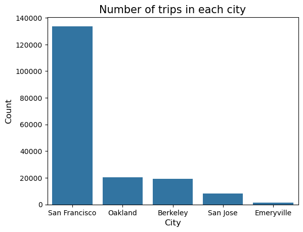

```python
# Create a countplot
order_city = bikedata_explore['city'].value_counts().sort_values(ascending=False).index
sb.countplot(data=bikedata_explore, x='city', color=base_color, order = order_city)
# Display the plot
plt.xlabel('City',size=12)
plt.ylabel('Count',size=12)
plt.title('Number of trips in each city',size=15)
plt.show();
```

> San Francisco was the city with the most trips counted

`5.` Number of trips by User types:

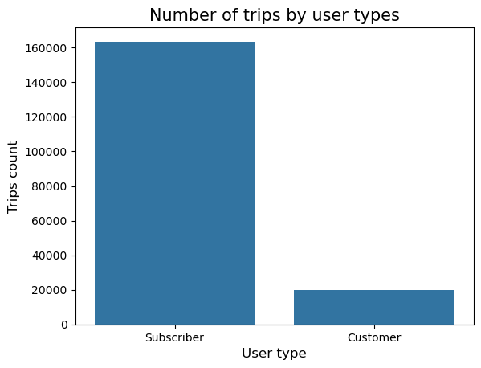

```python
types_order = bikedata_explore['user_type'].value_counts().index
sb.countplot(data=bikedata_explore,x='user_type',color=base_color,order=types_order);
plt.ylabel('Trips count',size=12)
plt.xlabel('User type',size=12)
plt.title('Number of trips by user types',size=15);
```

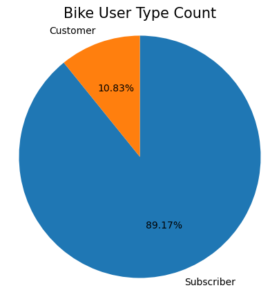

```python
# Show user type by it's percentage
plt.figure(figsize=(5,5))
sorted_counts = bikedata_explore['user_type'].value_counts()
plt.pie(sorted_counts, labels = sorted_counts.index, startangle = 90,
        counterclock = False, autopct='%1.2f%%');
plt.axis('square')
plt.title('Bike User Type Count', fontsize=15);
```

> The number of trips by subscribers, 8 times as much as that of customers.

`6.` Number of trips by bike sharing options:

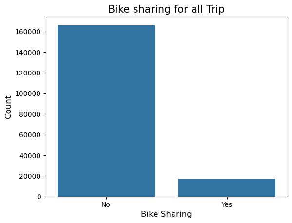

```python
sb.countplot(data=bikedata_explore,x='bike_share_for_all_trip',color=base_color)
plt.xlabel('Bike Sharing',size=12)
plt.ylabel('Count',size=12)
plt.title('Bike sharing for all Trip',size=15);
```

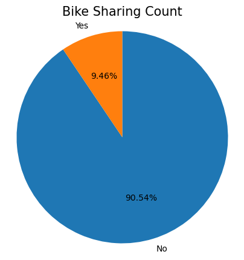

```python
# Show bikesharing options by it's percentage
plt.figure(figsize=(5,5))
sorted_counts = bikedata_explore['bike_share_for_all_trip'].value_counts()
plt.pie(sorted_counts, labels = sorted_counts.index, startangle = 90,
        counterclock = False, autopct='%1.2f%%');
plt.axis('square')
plt.title('Bike Sharing Count', fontsize=15);
```

> The number of non-bike sharing trips are significantly higher than the bike sharing trips

`7.` Number of trips by users genders:

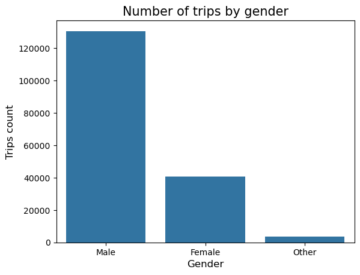

```python
sb.countplot(data=bikedata_explore,x='member_gender',color=base_color,order=['Male','Female','Other']);
plt.ylabel('Trips count',size=12)
plt.xlabel('Gender',size=12)
plt.title('Number of trips by gender',size=15);
```

> The dominating gender in trips count is Male.

`8.` Number of trips by users ages:

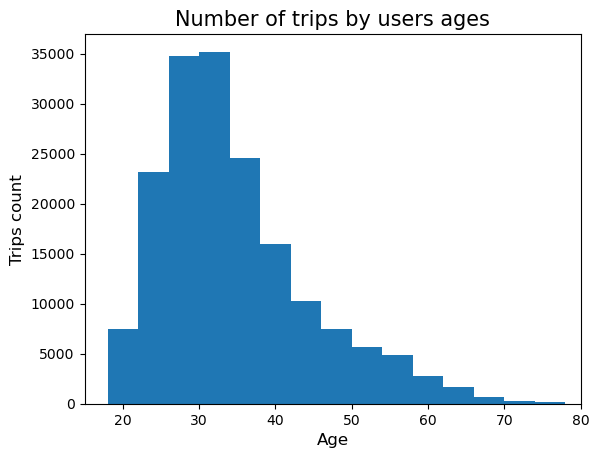

```python
bins=np.arange(18,81,4)
plt.hist(data=bikedata_explore[bikedata_explore['member_age'].notna()],x='member_age',color=base_color,bins = bins)
plt.ylabel('Trips count',size=12)
plt.xlabel('Age',size=12)
plt.xlim(15,80)
plt.title('Number of trips by users ages',size=15);
```

`9.` Stations data visualization:

`9.1` Number of stations per each city:

```python
#Number of stations by each city:
station['city'].value_counts()
#Correct the city of 2 stations in 'Santa Clara':
station.loc[station['city'] == 'Santa Clara','city'] = 'San Jose'
```

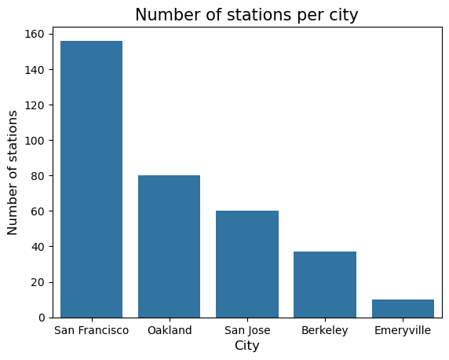

```python
#Visualize the number of stations per each city:
sb.countplot(data=station,x='city',color=base_color)
plt.xlabel('City',size=12)
plt.ylabel('Number of stations',size=12)
plt.title('Number of stations per city',size=15)
plt.show();
```

> San Francisco was the city with the most stations number.

`9.2` Ratio of trip/station in each city:

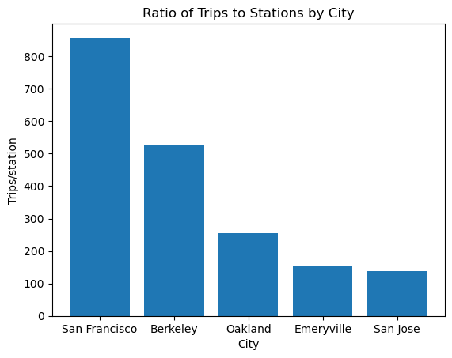

```python
ratio = bikedata_explore['city'].value_counts() / station['city'].value_counts()
# Sort the data in descending order
ratio_sorted = ratio.sort_values(ascending=False)
# Create the bar plot with sorted data
plt.bar(ratio_sorted.index, ratio_sorted.values)
# Add labels and title
plt.xlabel('City')
plt.ylabel('Trips/station')
plt.title('Ratio of Trips to Stations by City')
plt.show();
```

> San Francisco was the city with the highest trips started per station.

`9.3` Most common start/end stations:

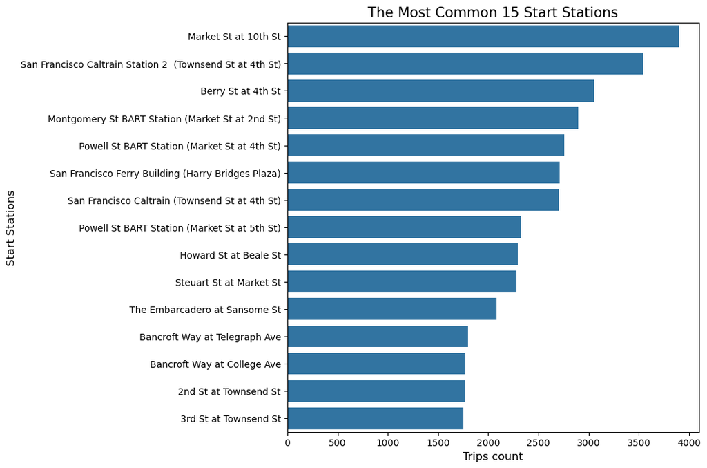

```python
#Most common 15 start/end stations:
"""
    Arange 15 most frequent used start or end stations

    Parameters:
    station (str): Start/end station. Valid value are 'start' or 'end'

    Returns:
    sub: dataset of 15 most common stations
    order: order of 15 station above
"""
def most_15(station):
    if station == 'start':
        counts = bikedata_explore['start_station_name'].value_counts().reset_index(name='number_of_trips')[:15]
        order=counts['index']
        sub=bikedata_explore.loc[bikedata_explore['start_station_name'].isin(counts["index"])]
    elif station == 'end':
        counts = bikedata_explore['end_station_name'].value_counts().reset_index(name='number_of_trips')[:15]
        order=counts['index']
        sub=bikedata_explore.loc[bikedata_explore['end_station_name'].isin(counts["index"])]
    return sub,order

(start_sub,start_order) = most_15('start')
plt.figure(figsize=[8,8])
ax=sb.countplot(data=start_sub,y='start_station_name', color=base_color, order=start_order)
plt.ylabel('Start Stations',size=12)
plt.xlabel('Trips count',size=12)
plt.title('The Most Common 15 Start Stations',size=15);
```

> Station at 10th Market St. witnessed around 4 thoudsands trips started. Accounted for the most common start station in Feb 2019. Which is also the 2nd most common end station.

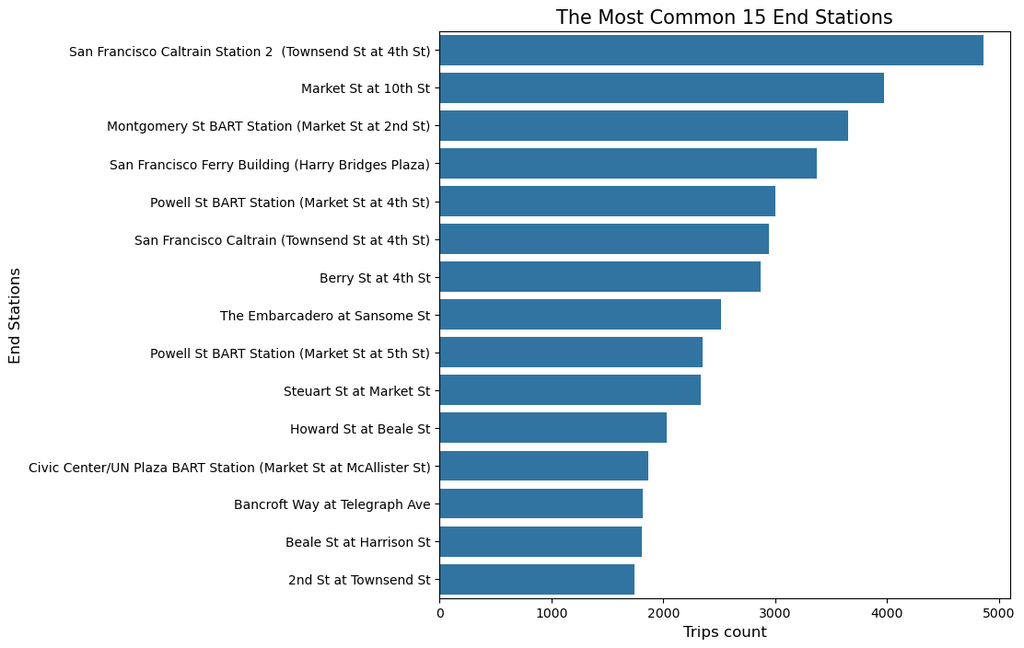

```python
(start_sub,start_order) = most_15('end')
plt.figure(figsize=[8,8])
ax=sb.countplot(data=start_sub,y='end_station_name', color=base_color, order=start_order)
plt.ylabel('End Stations',size=12)
plt.xlabel('Trips count',size=12)
plt.title('The Most Common 15 End Stations',size=15);
```

> Station at 2nd Townsend St. witnessed around 4.8 thoudsands trips ended. Accounted for the most common end station in Feb 2019. Which is also the 2nd most common start station.

`9.4` Least common start/end stations:

```python
#Least common 15 start/end stations:
"""
    15 least frequent used start or end stations

    Parameters:
    station (str): Start/end station. Valid value are 'start' or 'end'

    Returns:
    sub: dataset of 15 least common stations
    order: order of 15 station above
"""
def least_15(station):
    if station == 'start':
        counts = bikedata_explore['start_station_name'].value_counts(ascending=True).reset_index(name='number_of_trips')[:15]
        order=counts['index'][::-1]
        sub=bikedata_explore.loc[bikedata_explore['start_station_name'].isin(counts["index"])]
    elif station == 'end':
        counts = bikedata_explore['end_station_name'].value_counts(ascending=True).reset_index(name='number_of_trips')[:15]
        order=counts['index'][::-1]
        sub=bikedata_explore.loc[bikedata_explore['end_station_name'].isin(counts["index"])]
    return sub,order
```

```
14                      Empire St at 7th St
13                Williams Ave at Apollo St
12                Foothill Blvd at 42nd Ave
11               San Pedro St at Hedding St
10           26th Ave at International Blvd
9                 23rd Ave at Foothill Blvd
8                Farnam St at Fruitvale Ave
7                Leavenworth St at Broadway
6     Backesto Park (Jackson St at 13th St)
5                       Taylor St at 9th St
4                      Willow St at Vine St
3               Parker Ave at McAllister St
2            21st Ave at International Blvd
1                      Palm St at Willow St
0                             16th St Depot
Name: index, dtype: object
```

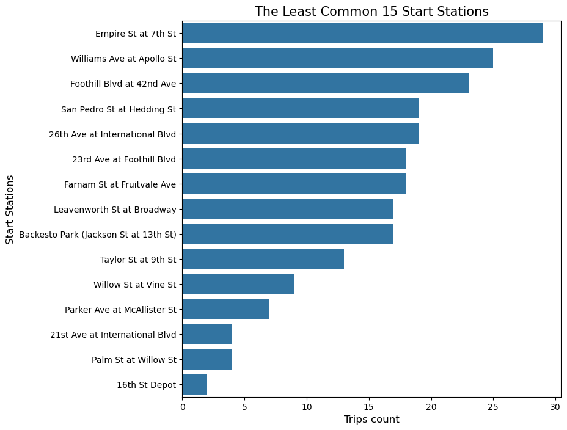

```python
#plotting least common start stations:
(start_sub,start_order) = least_15('start')
print(start_order)
plt.figure(figsize=[8,8])
ax=sb.countplot(data=start_sub,y='start_station_name', color=base_color, order=start_order)
plt.ylabel('Start Stations',size=12)
plt.xlabel('Trips count',size=12)
plt.title('The Least Common 15 Start Stations',size=15);
```

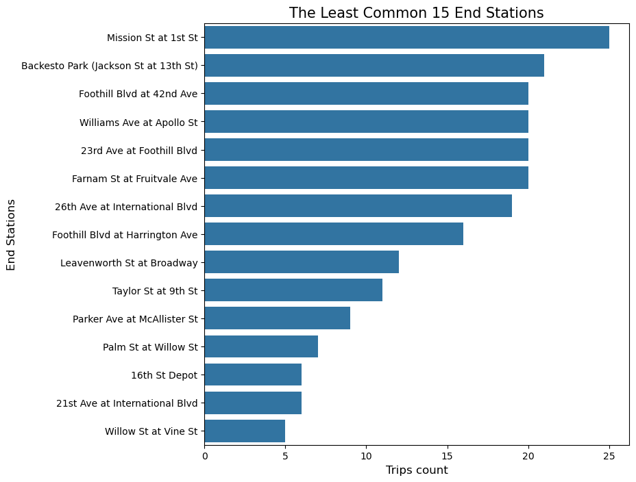

```python
#plotting least common end stations:
(start_sub,start_order) = least_15('end')
plt.figure(figsize=[8,8])
ax=sb.countplot(data=start_sub,y='end_station_name', color=base_color, order=start_order)
plt.ylabel('End Stations',size=12)
plt.xlabel('Trips count',size=12)
plt.title('The Least Common 15 End Stations',size=15);
```

> Station at Willow St. at Vine St. witnessed only 5 trips ended. Accounted for the least common end station in Feb 2019. Which is also the 5th least common start station with 9 trips started there.

### Of the features you investigated, were there any unusual distributions? Did you perform any operations on the data to tidy, adjust, or change the form of the data? If so, why did you do this?

> Some quality issues to this Ford GoBike data, such as:
> - In appropriate data type, need to be corrected.
> - I added 'city' comlumn, 'age' column based on customer's year of birth.
> - Missing customers' information in some entries (year of birth)
> - Dropped unused column in a separated dataset for exploration.

## Bivariate Exploration

> In this section, investigate relationships between pairs of variables in your data. Make sure the variables that you cover here have been introduced in some fashion in the previous section (univariate exploration).

`1.` Relation between ages and trips duration:

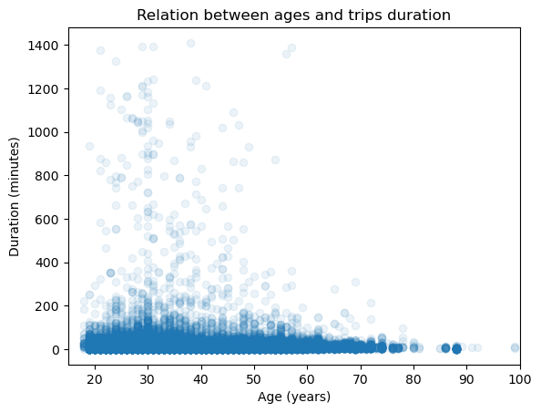

```python
sb.regplot(data=bikedata_explore,x='member_age',y='Duration_minutes',fit_reg=False, scatter_kws={'alpha':1/12})
plt.xlabel('Age (years)')
plt.xlim(15,100)
plt.ylabel('Duration (minutes)')
plt.title('Relation between ages and trips duration');
```

```python
#Correlation between duration and age:
bikedata_clean = bikedata_explore[bikedata_explore['member_age'].notna()]
bikedata_clean['member_age'] = bikedata_clean['member_age'].astype(float)
correlation = bikedata_clean['Duration_minutes'].corr(bikedata_clean['member_age'])
print("Correlation coefficient:", correlation)
```

```
Correlation coefficient: 0.006026742656500263
```

> Very weak positive correlation between the variables Duration_minutes and member_age.

`2.` Relation between subscription status and trips duration:

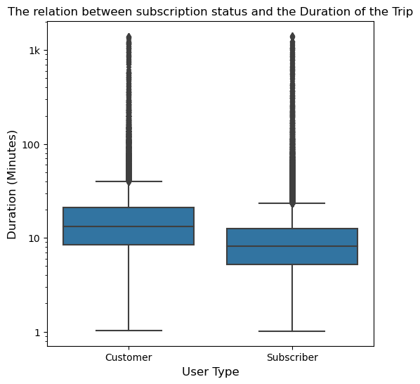

```python
plt.figure(figsize=[6,6])
sb.boxplot(data=bikedata_explore,x='user_type',y='Duration_minutes',color=base_color)
plt.yscale('log')
y_ticklocs=[1,10,100,1000]
y_ticklabels=['1','10','100','1k']
plt.yticks(y_ticklocs,y_ticklabels)
plt.xlabel('User Type',size=12)
plt.ylabel('Duration (Minutes)',size=12)
plt.title('The relation between subscription status and the Duration of the Trip');
```

> The above box plot shows that users who don't subribe have longer trips than subscribers.

`3.` Relation between city and trips duration:

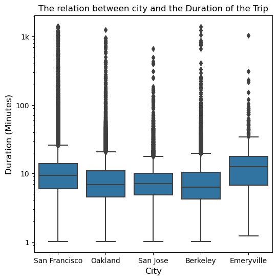

```python
plt.figure(figsize=[6,6])
sb.boxplot(data=bikedata_explore,x='city',y='Duration_minutes',color=base_color)
plt.yscale('log')
y_ticklocs=[1,10,100,1000]
y_ticklabels=['1','10','100','1k']
plt.yticks(y_ticklocs,y_ticklabels)
plt.xlabel('City',size = 12)
plt.ylabel('Duration (Minutes)',size=12)
plt.title('The relation between city and the Duration of the Trip');
```

> The above box plot shows that users in Emeryville had the longest trips.

`4.` Relation between trips' start time and trips duration:

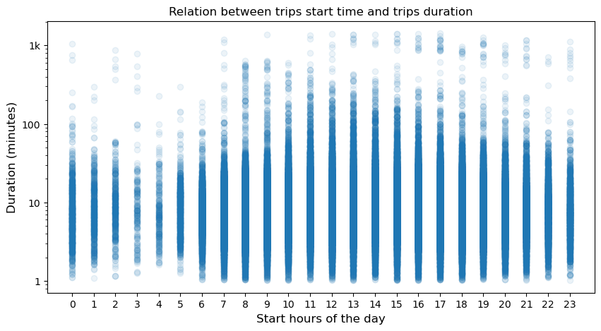

```python
plt.figure(figsize=(10,5))
sb.regplot(x=bikedata_explore['start_time'].dt.hour,y=bikedata_explore['Duration_minutes'],fit_reg=False, scatter_kws={'alpha':1/12})
plt.yscale('log')
y_ticklocs=[1,10,100,1000]
y_ticklabels=['1','10','100','1k']
x_tickloc = np.arange(0,24,1)
x_ticklabel = np.arange(0,24,1).astype(str)
plt.xticks(x_tickloc,x_ticklabel)
plt.yticks(y_ticklocs,y_ticklabels)
plt.xlabel('Start hours of the day',size=12)
plt.ylabel('Duration (minutes)',size=12)
plt.title('Relation between trips start time and trips duration');
```

> There's no significant connection between starts hour of trip to the duration of the trips.

`5.` Relation between genders and trips duration:

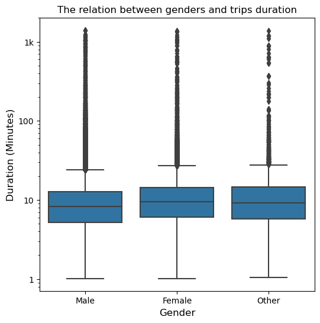

```python
plt.figure(figsize=[6,6])
sb.boxplot(data=bikedata_explore,x='member_gender',y='Duration_minutes',
            color=base_color,order=['Male','Female','Other'])
plt.yscale('log')
y_ticklocs=[1,10,100,1000]
y_ticklabels=['1','10','100','1k']
plt.yticks(y_ticklocs,y_ticklabels)
plt.xlabel('Gender',size=12)
plt.ylabel('Duration (Minutes)',size=12)
plt.title('The relation between genders and trips duration');
```

> The above box plot shows that males have shorter trips than other genders.

`6.` Relation between bike sharing trips and trips duration:

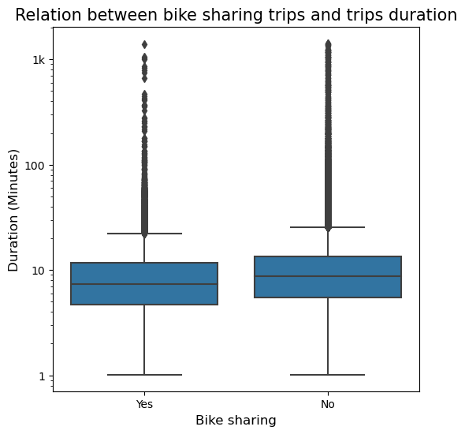

```python
plt.figure(figsize=[6,6])
sb.boxplot(data=bikedata_explore,x='bike_share_for_all_trip',y='Duration_minutes',
            color=base_color,order=['Yes','No'])
plt.yscale('log')
y_ticklocs=[1,10,100,1000]
y_ticklabels=['1','10','100','1k']
plt.yticks(y_ticklocs,y_ticklabels)
plt.xlabel('Bike sharing',size=12)
plt.ylabel('Duration (Minutes)',size=12)
plt.title('Relation between bike sharing trips and trips duration',size=15);
```

> The above box plot shows that bike sharing trips are shorter than those were without this option.

#### Other bivariate visualizations:

`7.` Trips counted in each city by Subcription status:

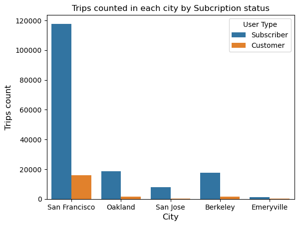

```python
sb.countplot(data=bikedata_explore,x='city',hue='user_type',hue_order=['Subscriber','Customer'])
#Plot labels and title
plt.xlabel('City',size=12)
plt.ylabel('Trips count',size=12)
plt.legend(title='User Type')
plt.title('Trips counted in each city by Subcription status');
```

> The number of trips by Subscriber in San Francisco dominated the total number of trips. In all city, the figure for trips by subcribers were higher than those by non-subscribers.

`8.` Trips counted in each city by gender:

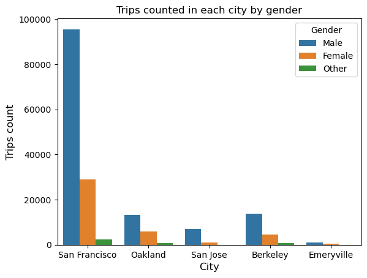

```python
sb.countplot(data=bikedata_explore,x='city',hue='member_gender',hue_order=['Male','Female','Other'])
#Plot labels and title
plt.xlabel('City',size=12)
plt.ylabel('Trips count',size=12)
plt.legend(title='Gender')
plt.title('Trips counted in each city by gender');
```

`9.` Relation between user ages and subcription:

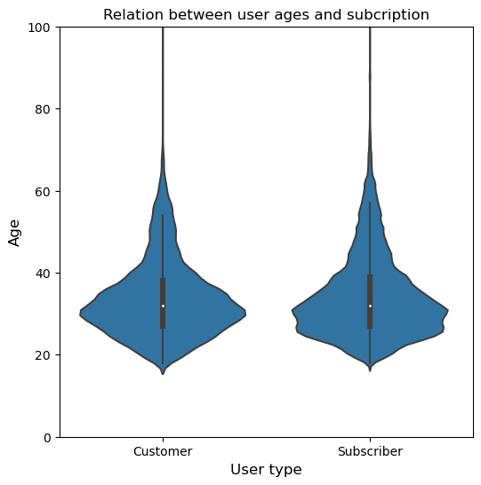

```python
plt.figure(figsize=[6,6])
clean_bikedata = bikedata_explore[bikedata_explore['member_age'].notna()]
clean_bikedata['member_age'] = clean_bikedata['member_age'].astype('float')
sb.violinplot(clean_bikedata,x='user_type',y='member_age',
             color=base_color)
#Plot labels and title
plt.ylim(0,100)
plt.xlabel('User type',size=12)
plt.ylabel('Age',size=12)
plt.title('Relation between user ages and subcription');
```

> It looks like there's no significant different in the violin plot of user age between customers and subcibers

`10.` Relation between user ages and gender:

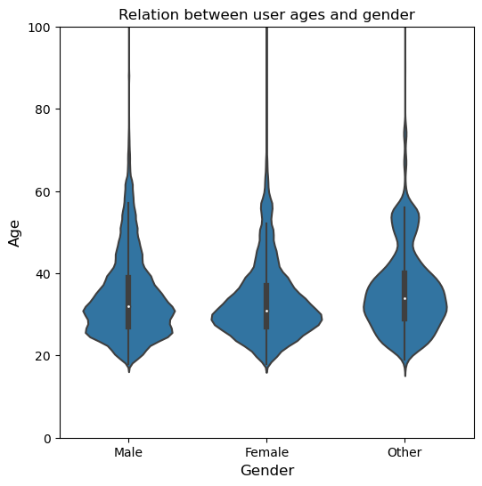

```python
plt.figure(figsize=[6,6])
clean_bikedata = bikedata_explore[bikedata_explore['member_age'].notna()]
clean_bikedata['member_age'] = clean_bikedata['member_age'].astype('float')
sb.violinplot(clean_bikedata,x='member_gender',y='member_age',
             color=base_color,order=['Male','Female','Other'])
#Plot labels and title
plt.ylim(0,100)
plt.xlabel('Gender',size=12)
plt.ylabel('Age',size=12)
plt.title('Relation between user ages and gender');
```

> It seems that to all genders, the popular age of users are around 30.

### Talk about some of the relationships you observed in this part of the investigation. How did the feature(s) of interest vary with other features in the dataset?

> - There is almost no linear relationship between the trips duration and member age.
> - Non-subscribers tend to have longer trips than subscribers.
> - Males tend to have shorter trips than the other genders.
> - User in Emneryville seems to have longest trips among all cities.
> - Bike sharing trips are shorter than those were without this option.
> - Large proportion of trips counted by Subsriber/non-subcribler are from San Francisco.

### Did you observe any interesting relationships between the other features (not the main feature(s) of interest)?

> - Among all cities, trips started by male are times higher than female/other counterparts.
> - Regardless gender, most of the customer ages are around 30.
> - There's no effect of customer age to the subscription status